# Autonomous Mobile Robots

## AMR_SS23_SensorDataFiltering

### General Information:

Please do not add or delete any cells. Answers belong into the corresponding cells (below the question). If a function is given (either as a signature or a full function), you should not change the name, arguments or return value of the function.  
If you encounter empty cells underneath the answer that can not be edited, please ignore them, they are for testing purposes.  
When editing an assignment there can be the case that there are variables in the kernel. To make sure your assignment works, please restart the kernel and run all cells before submitting (e.g. via *Kernel -> Restart & Run All* ).

Code cells where you are supposed to give your answer often include the line ```raise NotImplementedError```. This makes it easier to automatically grade answers. If you edit the cell please outcomment or delete this line.

### Submission:

Please submit your notebook via the web interface (in the main view -> Assignments -> Submit). The assignment is due on **14-05-2023** at **20:00 **.****

### Questions about the Assignment:

If you have questions about the assignment please post them in the LEA forum.

## Types of filtering

Familiarize with different types of filtering techniques on LIDAR data.For a given set of LIDAR data apply different types of filters and observe the results.

```python
import pandas as pd
import numpy as np
import matplotlib.pyplot as plt
```

### Median filter

Median filters are used to replace the outliers in the data by preserving the total number of data points.  
Application of median filter on the LIDAR data "scan000001.dat" (Source: Mobile Roboter, Herzberg) along with the plot of the results is presented below.

Vary the kernel size and observe the variation.

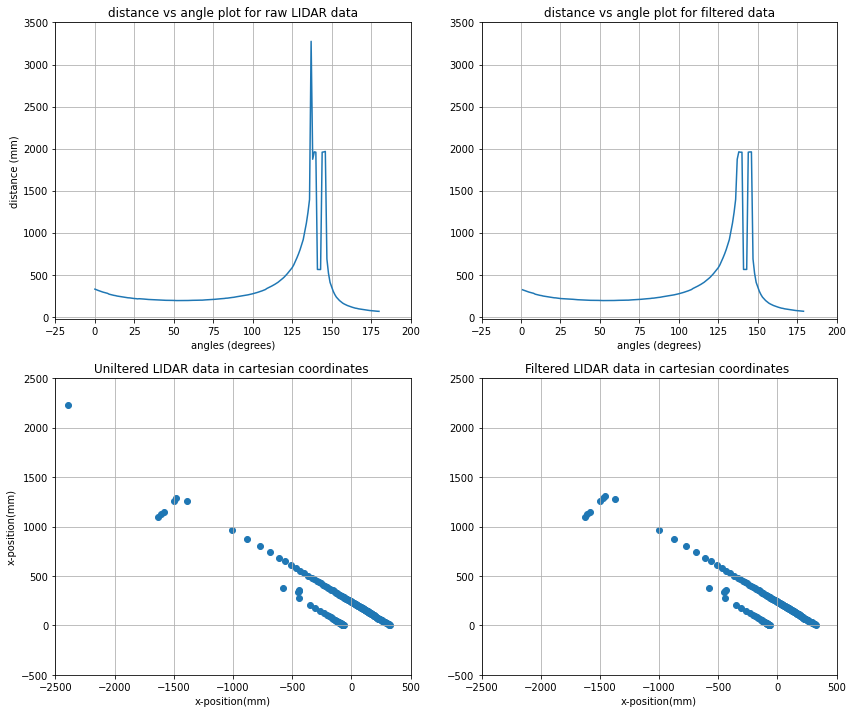

```python
def np_polar2rect(np_array):
    center = np.array([0,0])
    r = np_array.T[0,]
    theta = np_array.T[1,]
    x = r*np.cos(np.deg2rad(theta))
    y = r*np.sin(np.deg2rad(theta))
    return np.array([x, y]).T

df = pd.read_table("AMR_SS23_SensorDataFiltering_files/data/scan000001.dat", skiprows=[0], sep='\n', names=["distance"], header=None)
df["angle"] = range(0,181)

data_points_unfiltered = np.array(df[['distance', 'angle']])

k = 3
df_median = df.rolling(k, axis=0).median().dropna()
data_points = np.array(df_median[['distance', 'angle']])

fig, axs = plt.subplots(2, 2, figsize=(14,12))
axs[0, 0].set_title("distance vs angle plot for raw LIDAR data")
axs[0, 0].plot(data_points_unfiltered[:,1], data_points_unfiltered[:,0])
axs[0, 0].set(xlabel="angles (degrees)", ylabel="distance (mm)")
axs[0, 0].set_xlim([-25, 200])
axs[0, 0].set_ylim([-25, 3500])
axs[0, 0].grid()

axs[0, 1].set_title("distance vs angle plot for filtered data")
axs[0, 1].plot(data_points[:,1], data_points[:,0])
axs[0, 1].set(xlabel="angles (degrees)")
axs[0, 1].set_xlim([-25, 200])
axs[0, 1].set_ylim([-25, 3500])
axs[0, 1].grid()

axs[1, 0].set_title("Uniltered LIDAR data in cartesian coordinates ")
axs[1, 0].scatter(np_polar2rect(data_points_unfiltered)[:,0], np_polar2rect(data_points_unfiltered)[:,1])
axs[1, 0].set(xlabel="x-position(mm)", ylabel="x-position(mm)")
axs[1, 0].set_xlim([-2500, 500])
axs[1, 0].set_ylim([-500, 2500])
axs[1, 0].grid()

axs[1, 1].set_title("Filtered LIDAR data in cartesian coordinates ")
axs[1, 1].scatter(np_polar2rect(data_points)[:,0], np_polar2rect(data_points)[:,1])
axs[1, 1].set(xlabel="x-position(mm)")
axs[1, 1].set_xlim([-2500, 500])
axs[1, 1].set_ylim([-500, 2500])
axs[1, 1].grid()

# YOUR CODE HERE
# raise NotImplementedError()
```

### Mean filter

Application of mean filter on the LIDAR data "scan000001.dat" (Source: Mobile Roboter, Herzberg) along with the plot of the results is presented below.

Vary the kernel size and observe the variation.

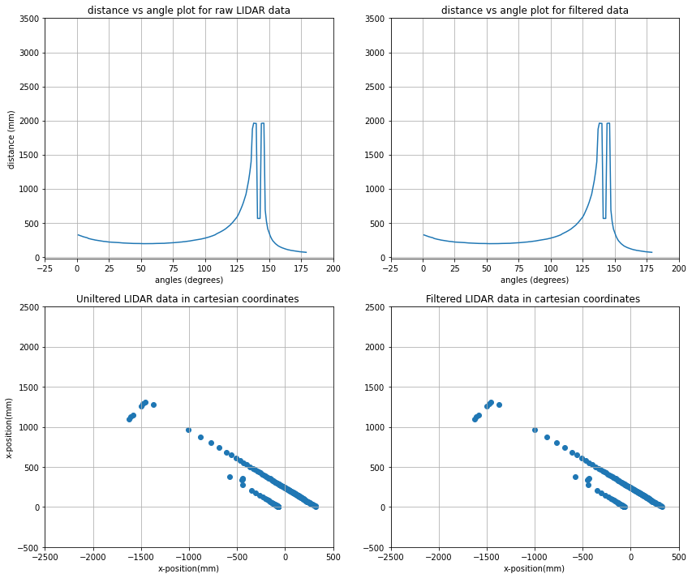

```python
def np_polar2rect(np_array):
    center = np.array([0,0])
    r = np_array.T[0,]
    theta = np_array.T[1,]
    x = r*np.cos(np.deg2rad(theta))
    y = r*np.sin(np.deg2rad(theta))
    return np.array([x, y]).T

df = pd.read_table("AMR_SS23_SensorDataFiltering_files/data/scan000001.dat", skiprows=[0], sep='\n', names=["distance"], header=None)
df["angle"] = range(0,181)

data_points_unfiltered = np.array(df_median[['distance', 'angle']])

k = 1
df_avg = df_median.rolling(k, axis=0).mean().dropna()
data_points = np.array(df_avg[['distance', 'angle']])

fig, axs = plt.subplots(2, 2, figsize=(14,12))
axs[0, 0].set_title("distance vs angle plot for raw LIDAR data")
axs[0, 0].plot(data_points_unfiltered[:,1], data_points_unfiltered[:,0])
axs[0, 0].set(xlabel="angles (degrees)", ylabel="distance (mm)")
axs[0, 0].set_xlim([-25, 200])
axs[0, 0].set_ylim([-25, 3500])
axs[0, 0].grid()

axs[0, 1].set_title("distance vs angle plot for filtered data")
axs[0, 1].plot(data_points[:,1], data_points[:,0])
axs[0, 1].set(xlabel="angles (degrees)")
axs[0, 1].set_xlim([-25, 200])
axs[0, 1].set_ylim([-25, 3500])
axs[0, 1].grid()

axs[1, 0].set_title("Uniltered LIDAR data in cartesian coordinates ")
axs[1, 0].scatter(np_polar2rect(data_points_unfiltered)[:,0], np_polar2rect(data_points_unfiltered)[:,1])
axs[1, 0].set(xlabel="x-position(mm)", ylabel="x-position(mm)")
axs[1, 0].set_xlim([-2500, 500])
axs[1, 0].set_ylim([-500, 2500])
axs[1, 0].grid()

axs[1, 1].set_title("Filtered LIDAR data in cartesian coordinates ")
axs[1, 1].scatter(np_polar2rect(data_points)[:,0], np_polar2rect(data_points)[:,1])
axs[1, 1].set(xlabel="x-position(mm)")
axs[1, 1].set_xlim([-2500, 500])
axs[1, 1].set_ylim([-500, 2500])
axs[1, 1].grid()

# YOUR CODE HERE
# raise NotImplementedError()
```

### Reduction filter

Reduction filters are used to reduce number of data points and to reducee the noise. A cluster of data points are replaced with their representative.  
Application of reduction filter on the LIDAR data "scan000001.dat" (Source: Mobile Roboter, Herzberg) along with the plot of the results is presented below.

Vary the kernel size and observe the variation.

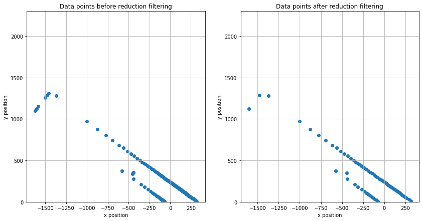

```python
def reduction_filter(data_points, sigma, k):
    '''
    Method to reduce number of laser scan points by replacing cluster of points
    with their representative.
    :param data_points: 2D array representing laser scan data in polar coordinates
    :param type: np.ndarray
    :param sigma: maximum distance between two consecutive points to consider them
    in same cluster
    :param type: float
    :param k: maximum number of points allowed in a cluster
    :param type: int
    '''
    points_list = list(data_points)
    output = []
    # while points_list is not empty
    while len(points_list) > 0:
        a_i = points_list.pop(0)
        cur_sum = np.array(a_i)
        i = 1
        # collect all points that belongs to a cluster
        while len(points_list) > 0 and abs(a_i[0] - points_list[0][0]) < sigma and i <= k:
            cur_sum += np.array(points_list.pop(0))
            i += 1
        # taking mean of distance and angle of the cluster to find its representative point
        output.append(cur_sum/i)
    return np.array(output)

data_points = np.array(df_avg[['distance', 'angle']])

reduced_points = np_polar2rect(reduction_filter(data_points, 20, 3))

fig = plt.figure(figsize=(14,7))
fig.add_subplot(121)
plt.scatter(np_polar2rect(data_points)[:,0], np_polar2rect(data_points)[:,1])
plt.title("Data points before reduction filtering")
plt.xlabel("x position")
plt.ylabel("y position")
plt.ylim(0, 2300)
plt.grid()

fig.add_subplot(122)
plt.scatter(reduced_points[:,0], reduced_points[:,1])
plt.title("Data points after reduction filtering")
plt.xlabel("x position")
plt.ylabel("y position")
plt.ylim(0, 2300)
plt.grid()
plt.show()

# YOUR CODE HERE
# raise NotImplementedError()
```

### Comparison

Please answer these questions for your future reference

1. What are the advantages and disadvantages of using median filter?
2. What are the advantages and disadvantages of using mean filter?
3. What are the advantages and disadvantages of using reduction filter?

## Median Filter:

**Advantages:**

- I really like using a median filter when I'm dealing with data that has some random little specks or spots that are totally different from everything else. It's really good at getting rid of these without messing up the rest of the data.
- Also, it's not bothered by really big or small numbers that don't fit with the rest of my data. It just kind of ignores them, which can be super useful.

**Disadvantages:**

- Now, where the median filter doesn't shine as much is when dealing with noise that's more spread out, like a sort of blurry mess across my data. It's not the best at cleaning that up.
- And if my data has lots of noise or if the noise is similar to the real data, the median filter can struggle a bit.

## Mean Filter:

**Advantages:**

- When I have data that's a bit blurry or where the noise is spread out, I tend to reach for the mean filter. It's really good at smoothing things out and making everything more consistent.
- Plus, if my data is more or less following a certain trend or pattern, the mean filter can help bring that out more clearly.

**Disadvantages:**

- One thing I need to watch out for with the mean filter is that it can sometimes oversmooth my data. This could hide some important details or make everything look too simple.
- Also, it's more sensitive to those big or small numbers that don't fit with the rest of the data. If I have too many of these, they can really skew the results and make the mean filter less effective.

## Reduction Filter:

**Advantages:**

- The reduction filter is a big help when I have a ton of data and I just want to simplify things. It groups similar data points together and replaces them with a single point, which can make everything a lot easier to handle.
- It also tends to preserve the overall shape or structure of my data, which is great when I want to keep the big picture without getting lost in the details.

**Disadvantages:**

- However, the reduction filter does have its downsides. One is that it can sometimes oversimplify my data, and I might lose some important details or nuances.
- Also, deciding on how to group the data points (like how similar they need to be to go in the same group) can be a bit tricky. If I don't get this right, the reduction filter might not work as well.

## Applying filters on LIDAR data

### Record bag files

Install ros2 bag package in ros_rolling sourced terminal (one time activity)

**sudo apt-get install ros-rolling-ros2bag**

Once the robot is running, collect the laser scan data by recording the data published on the /scan topic. (verify the topic name on the robot). For example, when recording the feature of parallel walls, this command can be used:

**ros2 bag record /scan -o parallel_walls**

Similarly, for following states collect the data. In above command, replace 'parallel_walls' by coresponding feature names):

1. parallel_wall
2. aligned_to_wall
3. corner_on_right
4. corner_on_left
5. corridor_intersection

### Save the data

Once you have collected bag files of all features, play the individual recorded bag file and save the data under the field **ranges** *for one instance* of the message to a csv file.

Play the bag file in one terminal and get the output by echoing to the scan topic in another terminal:

**ros2 bag play** **ros2 topic echo --full-length /scan**

Replace with the corresponding file name. From the above example, the command would be: *ros2 bag play parallel_walls*

Open a speadsheet and copy the data under **ranges** field to it. Save this file as a csv file. (While copying the data, choosing 'space' as delimeter and deleting the first column of '-' symbol should make this file ready to use).

### Process the data

Now upload this file to the **data/** folder of this notebook and replace the 'example_filter_data.csv' in the below cell with the respective file names.

Update the **min_angle_rad** and **max_angle_rad** variables by referring to the header of the message when the message is echoed in the terminal.

Apply median, mean and reduction filter or combination of these on these features collected on ROBILE and tune the parameters accordingly.

Note: Update or comment the limits on the x and y-axis values while plotting

[output not shown]

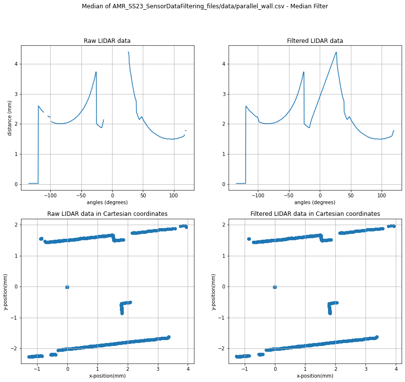

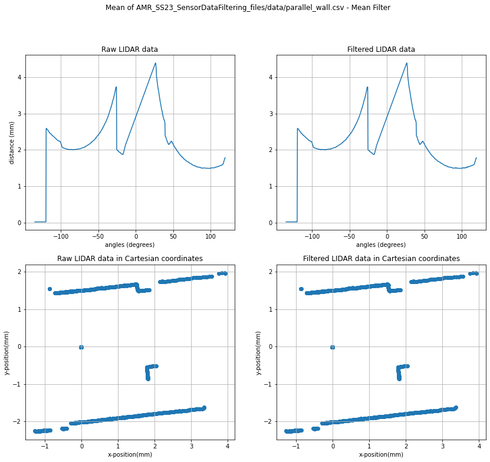

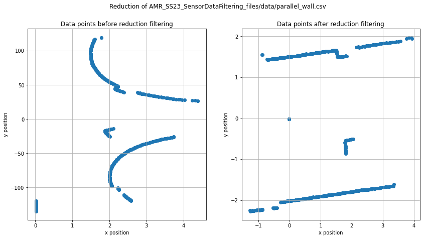

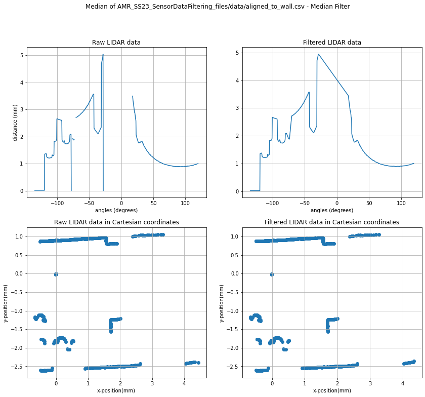

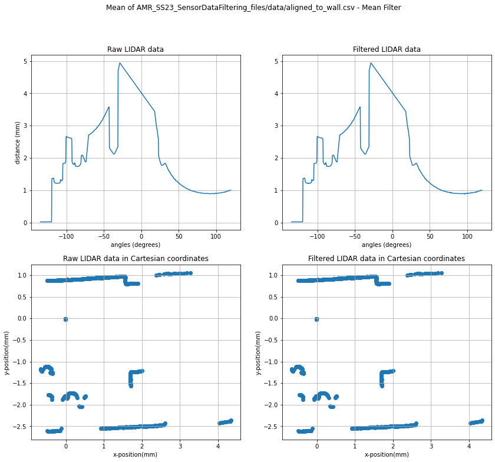

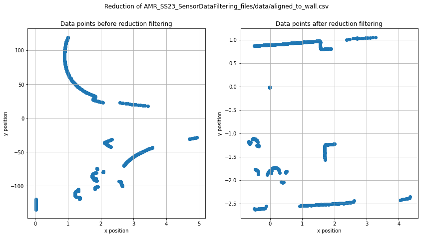

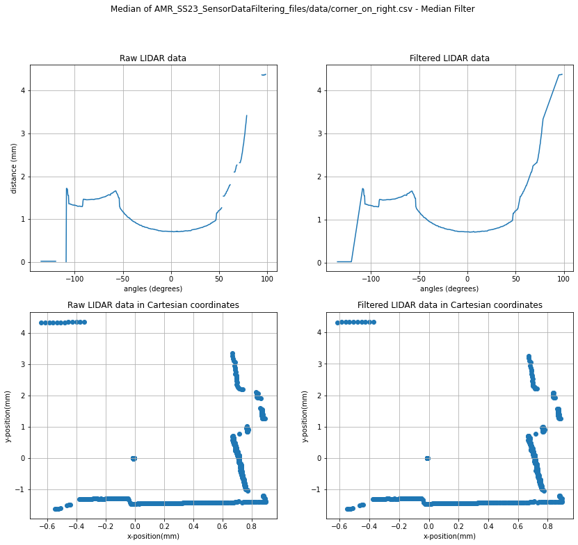

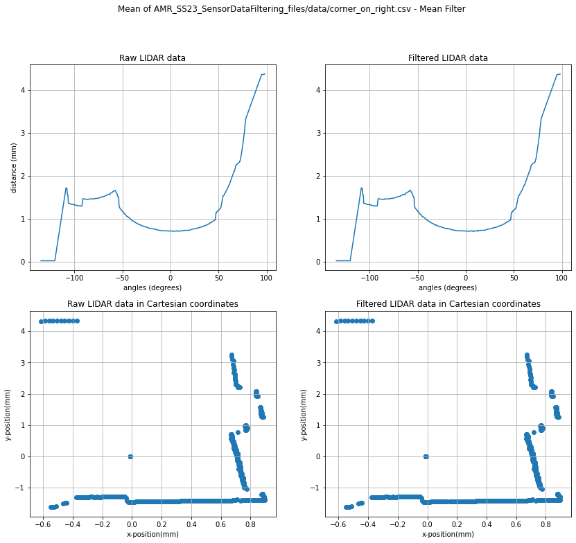

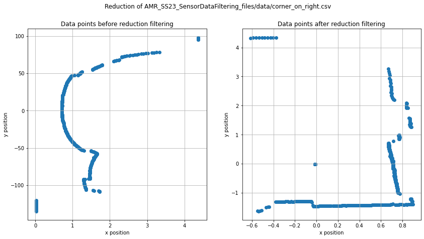

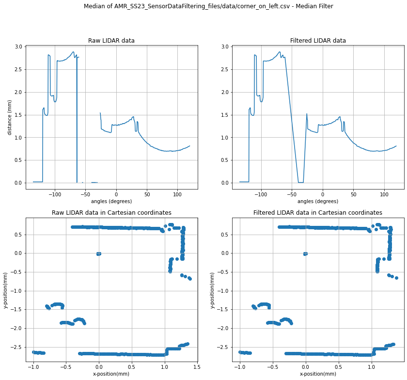

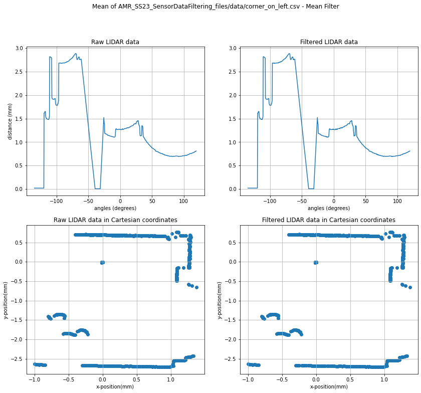

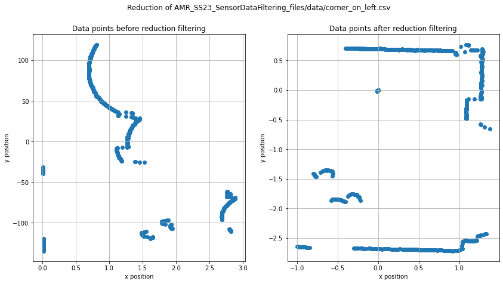

[6 more figures not shown]

```python
## to keep the names of all data set files consistent, please use these names:
# parallel_wall.csv, aligned_to_wall.csv, corner_on_right.csv, corner_on_left.csv, corridor_intersection.csv
import numpy as np
import pandas as pd
import matplotlib.pyplot as plt

# Function to convert polar coordinates to Cartesian
def polar_to_cartesian(polar_arr):
    origin = np.array([0,0])
    radius = polar_arr.T[0,]
    theta = polar_arr.T[1,]
    x_coord = radius * np.cos(np.deg2rad(theta))
    y_coord = radius * np.sin(np.deg2rad(theta))
    return np.array([x_coord, y_coord]).T

# Function to convert raw data to DataFrame
def raw_to_dataframe(raw_data):
    lower_limit_rad = -2.356194496154785
    upper_limit_rad = 2.0923497676849365

    raw_data[raw_data=='.inf'] = '0'
    data_float = np.array(raw_data, dtype=float)

    theta_values = np.linspace(lower_limit_rad, upper_limit_rad, data_float.shape[0])*180/np.pi
    combined_data = np.hstack([data_float.reshape(-1,1), theta_values.reshape(-1,1)])

    # Remove zero distance entries
    combined_data = np.delete(combined_data, np.where(combined_data[:, 0] == 0), axis=0)

    output_df = pd.DataFrame(combined_data, columns = ['distance','angles'])
    return output_df

# Function to plot data
def plot_data(unfiltered_data, filtered_data, title):
    fig, axs = plt.subplots(2, 2, figsize=(14,12))
    fig.suptitle(title)

    # Plot unfiltered data
    axs[0, 0].set_title("Raw LIDAR data")
    axs[0, 0].plot(unfiltered_data[:,1], unfiltered_data[:,0])
    axs[0, 0].set(xlabel="angles (degrees)", ylabel="distance (mm)")
    axs[0, 0].grid()

    # Plot filtered data
    axs[0, 1].set_title("Filtered LIDAR data")
    axs[0, 1].plot(filtered_data[:,1], filtered_data[:,0])
    axs[0, 1].set(xlabel="angles (degrees)")
    axs[0, 1].grid()

    # Plot unfiltered data in Cartesian coordinates
    axs[1, 0].set_title("Raw LIDAR data in Cartesian coordinates")
    axs[1, 0].scatter(polar_to_cartesian(unfiltered_data)[:,0], polar_to_cartesian(unfiltered_data)[:,1])
    axs[1, 0].set(xlabel="x-position(mm)", ylabel="y-position(mm)")
    axs[1, 0].grid()

    # Plot filtered data in Cartesian coordinates
    axs[1, 1].set_title("Filtered LIDAR data in Cartesian coordinates")
    axs[1, 1].scatter(polar_to_cartesian(filtered_data)[:,0], polar_to_cartesian(filtered_data)[:,1])
    axs[1, 1].set(xlabel="x-position(mm)", ylabel="y-position(mm)")
    axs[1, 1].grid()

    plt.show()

# Function to perform and visualize median filtering
def perform_median_filter(df, title):
    unfiltered_data_points = np.array(df[['distance', 'angles']])
    median_df = df.rolling(3, axis=0).median().dropna()
    filtered_data_points = np.array(median_df[['distance', 'angles']])

    plot_data(unfiltered_data_points, filtered_data_points, title + " - Median Filter")
    return median_df

def perform_mean_filter(df, title, window_size=5, std_multiplier=2):
    unfiltered_data_points = np.array(df[['distance', 'angles']])
    filtered_data_points = unfiltered_data_points.copy()  # Make a copy to avoid modifying original data

    for i in range(window_size, len(unfiltered_data_points)):
        window_data = unfiltered_data_points[i-window_size:i]
        mean = np.mean(window_data, axis=0)
        std_dev = np.std(window_data, axis=0)

        # If a point deviates more than 'std_multiplier' standard deviations from the mean,
        # replace it with the mean of the other points in the window
        for j in range(window_size):
            if np.any(np.abs(window_data[j] - mean) > std_multiplier * std_dev):
                filtered_data_points[i-window_size+j] = mean

    plot_data(unfiltered_data_points, filtered_data_points, title + " - Mean Filter")
    return pd.DataFrame(filtered_data_points, columns=['distance', 'angles'])

def reduction_filter(data_points, sigma, k_base, angle_factor):
    points_list = list(data_points)
    output = []
    # while points_list is not empty
    while len(points_list) > 0:
        a_i = points_list.pop(0)
        cur_sum = np.array(a_i)
        i = 1
        # adjust cluster size based on the angle
        k = int(k_base / (1 + (a_i[1]/angle_factor)**2))
        # collect all points that belongs to a cluster
        while len(points_list) > 0 and abs(a_i[0] - points_list[0][0]) < sigma and i <= k:
            cur_sum += np.array(points_list.pop(0))
            i += 1
        # taking mean of distance and angle of the cluster to find its representative point
        output.append(cur_sum/i)
    return np.array(output)

def plot_data_before_and_after_reduction(data_points, reduced_points, title):
    fig = plt.figure(figsize=(14,7))
    fig.suptitle(title)
    fig.add_subplot(121)
    plt.scatter(data_points[:,0], data_points[:,1])
    plt.title("Data points before reduction filtering")
    plt.xlabel("x position")
    plt.ylabel("y position")
    plt.grid()

    fig.add_subplot(122)
    plt.scatter(reduced_points[:,0], reduced_points[:,1])
    plt.title("Data points after reduction filtering")
    plt.xlabel("x position")
    plt.ylabel("y position")
    plt.grid()
    plt.show()


def process_data_from_csv(file_path):
    # Load data from the CSV file
    raw_data = np.loadtxt(file_path, dtype=str, usecols=[0])
    # Replace string '.nan' with '0'
    raw_data = np.where(raw_data == '.nan', 0.0, raw_data)

    # Convert raw data to DataFrame
    df = raw_to_dataframe(raw_data)

    # Perform and visualize median filtering
    median_df = perform_median_filter(df, f"Median of {file_path}")

    # Perform and visualize mean filtering
    mean_df = perform_mean_filter(median_df, f"Mean of {file_path}")

    # Perform and visualize reduction filtering
    data_points = mean_df[['distance', 'angles']].values.astype(float)
#     reduced_points = reduction_filter(data_points, 20, 2)
    reduced_points = reduction_filter(data_points, sigma=30, k_base=5, angle_factor=1)
    polar_to_rectangular = polar_to_cartesian(reduced_points)

    # Plot data before and after reduction filtering
    plot_data_before_and_after_reduction(data_points, polar_to_rectangular, f"Reduction of {file_path}")


process_data_from_csv('AMR_SS23_SensorDataFiltering_files/data/parallel_wall.csv')
process_data_from_csv('AMR_SS23_SensorDataFiltering_files/data/aligned_to_wall.csv')
process_data_from_csv('AMR_SS23_SensorDataFiltering_files/data/corner_on_right.csv')
process_data_from_csv('AMR_SS23_SensorDataFiltering_files/data/corner_on_left.csv')
process_data_from_csv('AMR_SS23_SensorDataFiltering_files/data/corridor_intersection.csv')
process_data_from_csv('AMR_SS23_SensorDataFiltering_files/data/glass_door.csv')
```

```python
min_angle_rad = -2.356194496154785
max_angle_rad = 2.0923497676849365
angle_increment = 0.006135923322290182

print("total angle = ", (max_angle_rad - min_angle_rad)*180/np.pi)
print("total points should be = ", (max_angle_rad - min_angle_rad)/angle_increment)
```

```
total angle =  254.8828112951478
total points should be =  724.9999763979025
```

### Parameters

By examining the above plots, list all the parameters that suits your data.

Timestamp:

# 2023-05-14 20:30:54.807006 CEST

Ihr Hashcode:

# 791926-669ad3-32f535-5eab9c